# COD Reproducibility Report

#### Methods summary:

The authors are interested in coordinated movements in situations where co-actors share visual access to a scene and do not share visual access to a scene. Participants play a video game where you have to drag a cursor from a “space ship” to a “planet” on the computer screen, while occasionally having to avoid “asteriods”. The goal is to arrive at the planet at the same time as your partner, and in some conditions, you can see your partner’s screen (“visible” condition) and in others, there is a sheet separating the two of you so you cannot see the partner’s screen (“hidden” condition). The authors have two measures: “mean time to target” (TT) and area under the curve of the trajectory (AUC). These are compared via their means and standard deviations, both normalized and unnormalized.

#### Target outcomes:

> 3.1. Effects of visibility We compared co-actors’ normalized performance between the ‘hidden’ and ‘visible’ conditions (Fig. 2; for the non-normalized data see Table 1). In line with our hypothesis that co-actors would try to reduce the temporal variability of their actions when they could not see each other, performance was not only faster (smaller normalized TTmean), t(15) = −3.29, p < 0.01, Cohen’s d = −0.82, but also less variable (smaller normalized TTvariability), t(15) = −2.52, p < 0.05, Cohen’s d = −0.63, in the ‘hidden’ condition. In line with our hypothesis that co-actors would modulate movement parameters in a communicative manner when they could see each other, the analysis of normalized AUCmean showed a larger area under the curve in the ‘visible’ condition, t(15) = −3.82, p < 0.01, Cohen’s d = −0.96. The difference in variability of curvature (normalized AUCvariability), t(15) = −1.4, p > 0.1, Cohen’s d = −0.35, was not significant.

## Step 1: Load packages

```r
library(tidyverse) # for data munging
library(knitr) # for kable table formating
library(haven) # import and export 'SPSS', 'Stata' and 'SAS' Files
library(readxl) # import excel files
library(CODreports) # custom report functions
library(effsize)
```

## Step 2: Load data

```r
df <- read.csv("data/data.csv")
str(df)
```

```
## 'data.frame':    12288 obs. of  13 variables:
##  $ Pair                                                    : int  1 1 1 1 1 1 1 1 1 1 ...
##  $ Subject                                                 : int  1 1 1 1 1 1 1 1 1 1 ...
##  $ Condition.individual.pre.hidden.visible.individual.post.: int  1 1 1 1 1 1 1 1 1 1 ...
##  $ Block                                                   : int  1 1 1 1 1 1 1 1 1 1 ...
##  $ Trial                                                   : int  1 2 3 4 5 6 7 8 9 10 ...
##  $ StimulusType                                            : int  210 120 211 111 121 220 110 211 221 121 ...
##  $ TargetSize.small.large.                                 : int  2 1 2 1 1 2 1 2 2 1 ...
##  $ TargetPosition.center.margin.                           : int  1 2 1 1 2 2 1 1 2 2 ...
##  $ ObstaclePresence.absent.present.                        : int  0 0 1 1 1 0 0 1 1 1 ...
##  $ Error.yes.no.                                           : int  0 0 0 0 1 0 0 0 0 0 ...
##  $ TT                                                      : num  1.294 0.743 0.834 1.043 0.615 ...
##  $ AUC                                                     : num  28.6 16.6 184.3 161 0 ...
##  $ Asynchrony                                              : num  -1 -1 -1 -1 -1 -1 -1 -1 -1 -1 ...
```

Many of the column names are of the form “Title (value1, value2)”. I assume the “value1” and “value2” correspond to the labels of the factor, in numerical order. For example, if the column has values 1 and 2, and the header says “Target Position (center / margin)”, it will be assumed that “center” = 1 and “margin” = 2.

However, in their Error column, it is listed “Error (yes / no)”. Following the convention I describe above, that would mean that Yes Error corresponds to 0 and No Error corresponds to 1. I think that is unlikely (plus, there are many more 0s than 1s), so I will treat 0 as No Error and 1 as Error.

## Step 3: Tidy data

```r
df.tidy <- df %>%
  mutate(Condition = factor(Condition.individual.pre.hidden.visible.individual.post.,
                            levels = c(1,2,3,4),
                            labels = c("Individual Pre", "Hidden",
                                       "Visible", "Individual Post")),
         TargetSize = factor(TargetSize.small.large., levels = c(1,2),
                             labels = c("small", "large")),
         TargetPosition = factor(TargetPosition.center.margin.,
                                 levels = c(1, 2),
                                 labels = c("center", "margin")),
         ObstaclePresence = factor(ObstaclePresence.absent.present.,
                                   levels = c(0, 1),
                                   labels = c("absent", "present")),
         Error = Error.yes.no.) %>%
  select(-Condition.individual.pre.hidden.visible.individual.post.,
         -TargetSize.small.large.,
         -TargetPosition.center.margin.,
         -ObstaclePresence.absent.present.,
         -Error.yes.no.)
```

## Step 4: Run analysis

### Pre-processing

From Section 2.3 Data Analysis:

> Trials in which partic- ipants’ TT was more than 1600 ms or in which they touched an obstacle were excluded (1.2% of all trials).

```r
df.tidy <- df.tidy %>%
  mutate(excluded = ifelse((TT > 1.6) | (Error == 1), 1, 0))

mean(df.tidy$Error)
```

```
## [1] 0.01350911
```

```r
mean(df.tidy$excluded)
```

```
## [1] 0.01350911
```

Looks like the “Error” column includes all the cases where TT > 1.6 as well as some more (possibly the other exclusion criterion: participant touched an obstacle). But I get 1.3509115 excluded, whereas the authors report 1.2%.

> In order to not inflate statistical power, dependent variables from the remaining trials were first aggregated on an individual participant level and then averaged over the two members of a pair. All dependent variables (TT, AUC, asynchrony; reported in Table 1) were normalized by dividing data from each joint condition by the ‘individual (pre)’ con- dition acquired in the beginning of the experiment.

```r
df.pair.condition.summary <- df.tidy %>%
  filter(!excluded) %>%
  group_by(Pair, Subject, Condition) %>%
  summarize(TT_mean = mean(TT),
            TT_variability = sd(TT),
            AUC_mean = mean(AUC),
            AUC_variability = sd(AUC),
            Asynchrony_mean = mean(Asynchrony)) %>%
  ungroup() %>%
  group_by(Pair, Condition) %>%
  summarize(TT_mean = mean(TT_mean),
            TT_variability = mean(TT_variability),
            AUC_mean = mean(AUC_mean),
            AUC_variability = mean(AUC_variability),
            Asynchrony_mean = mean(Asynchrony_mean)) %>%
  gather(key, value, -Pair, -Condition) %>%
  spread(Condition, value) %>%
  mutate(Hidden_normalized = Hidden / `Individual Pre`,
         Visible_normalized = Visible / `Individual Pre`)
```

> Normalized per- formance in the ‘hidden’ and ‘visible’ conditions were compared with pair-wise t-tests and also tested with one-sample t-tests against 1 to detect differences to baseline performance (‘individual (pre)’). Where appropriate, Bonferroni-correction was applied. The influence of TT and AUC on asynchrony was tested with separate multiple regression analyses (‘enter’ method, IBM SPSS 22).

### Descriptive statistics

```r
reported_descriptives <- list(
  TT_mean = -0.82,
  TT_variability = -0.63,
  AUC_mean = -0.96,
  AUC_variability = -0.35
)

d_TT_mean <- with(df.pair.condition.summary %>% filter(key == "TT_mean"),
     cohen.d(Hidden_normalized, Visible_normalized, paired = T))

d_TT_variability <- with(df.pair.condition.summary %>% filter(key == "TT_variability"),
     cohen.d(Hidden_normalized, Visible_normalized, paired = T))

d_AUC_mean <- with(df.pair.condition.summary %>% filter(key == "AUC_mean"),
     cohen.d(Hidden_normalized, Visible_normalized, paired = T))

d_AUC_variability <- with(df.pair.condition.summary %>% filter(key == "AUC_variability"),
     cohen.d(Hidden_normalized, Visible_normalized, paired = T))


compareValues(reported_descriptives$TT_mean, d_TT_mean$estimate)
```

```
## [1] "MINOR NUMERICAL ERROR. The reported value (-0.82) and the obtained value (-0.830892510138939) differed by 1.33%"
```

```r
compareValues(reported_descriptives$TT_variability, d_TT_variability$estimate)
```

```
## [1] "MINOR NUMERICAL ERROR. The reported value (-0.63) and the obtained value (-0.615000718551434) differed by 2.38%"
```

```r
compareValues(reported_descriptives$AUC_mean, d_AUC_mean$estimate)
```

```
## [1] "MINOR NUMERICAL ERROR. The reported value (-0.96) and the obtained value (-0.936738152121109) differed by 2.42%"
```

```r
compareValues(reported_descriptives$AUC_variability, d_AUC_variability$estimate)
```

```
## [1] "MAJOR NUMERICAL ERROR. The reported value (-0.35) and the obtained value (-0.590425390270985) differed by 68.69%"
```

3 minor numerical errors and 1 major numerical error for AUC_variability. Need to double check that one.

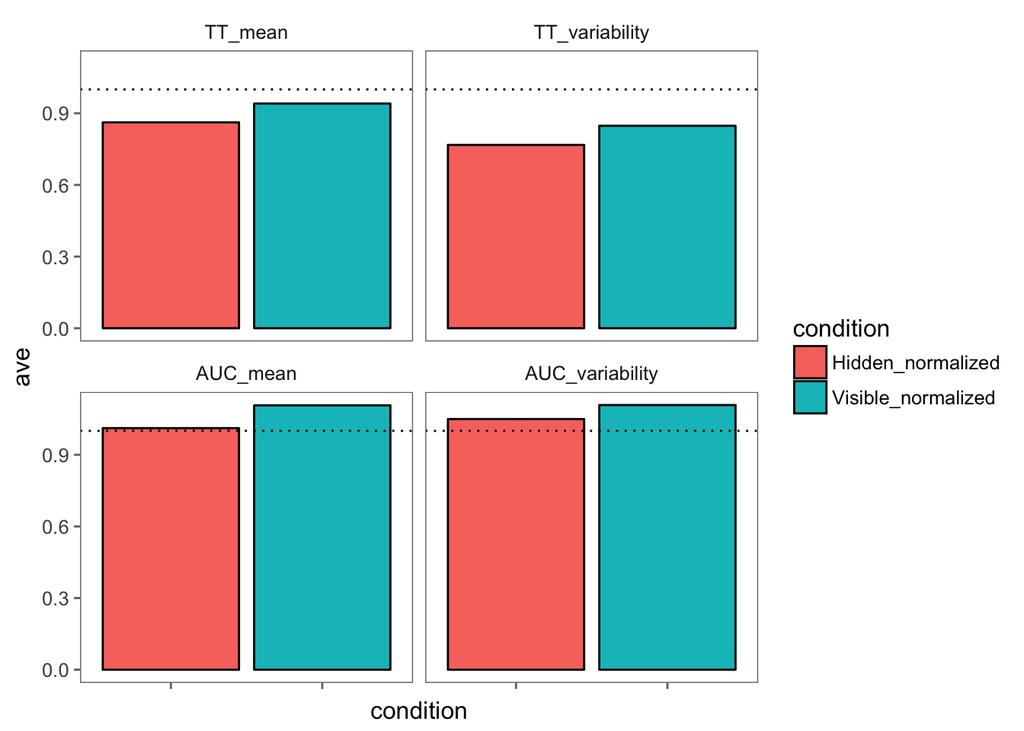

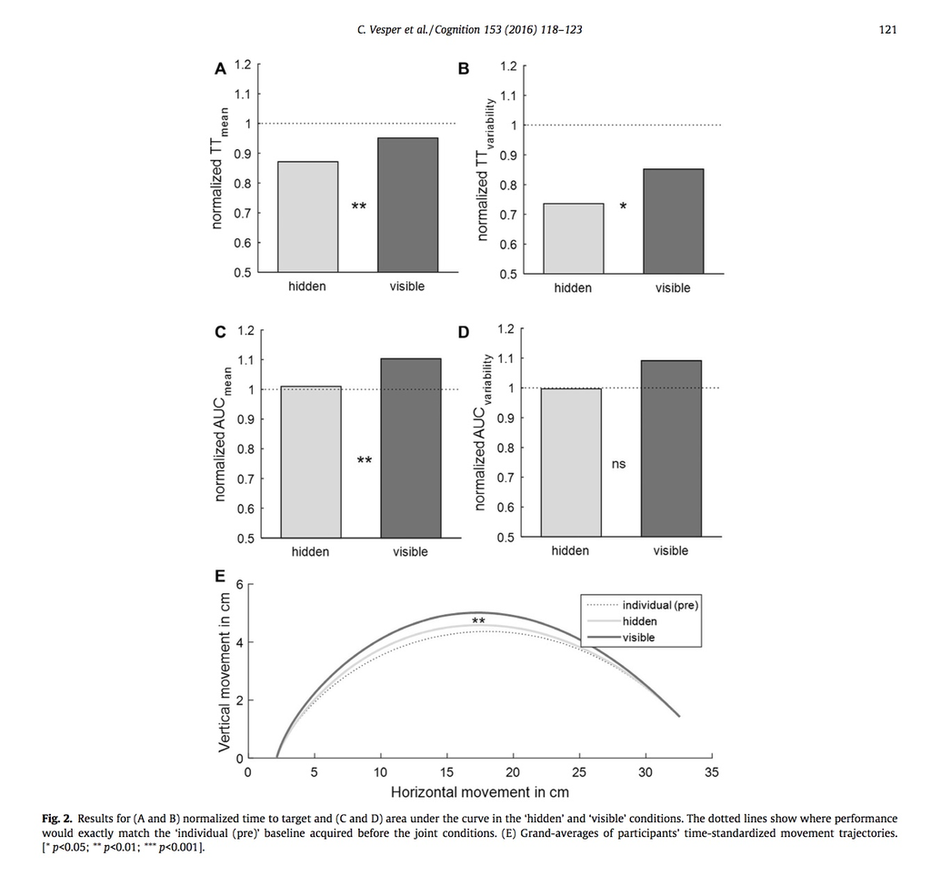

Figure 2 from paper

```r
df.pair.condition.summary %>%
  ungroup() %>%
  gather(condition, val, -key) %>%
  group_by(key, condition) %>%
  summarize(ave = mean(val)) %>%
  filter(condition %in% c("Hidden_normalized", "Visible_normalized"),
         key != "Asynchrony_mean") %>%
  ungroup() %>%
  mutate(key = factor(key, levels = c("TT_mean", "TT_variability",
                                      "AUC_mean", "AUC_variability"))) %>%
  ggplot(., aes(x = condition, y = ave, fill = condition))+
  geom_col(color = 'black')+
  facet_wrap(~key)+
  theme(axis.text.x = element_blank())+
  geom_hline(yintercept = 1, lty = 3)
```

```r
df.pair.condition.summary %>%
  ungroup() %>%
  gather(condition, val, -key, -Pair) %>%
  group_by(key, condition) %>%
  summarize(ave = mean(val),
            sd = sd(val) )%>%
  filter(!(condition %in% c("Hidden_normalized", "Visible_normalized"))) %>%
  ungroup() %>%
  mutate(key = factor(key, levels = c("TT_mean", "TT_variability",
                                      "AUC_mean", "AUC_variability",
                                      "Asynchrony_mean")),
         values = paste(
           as.character(round(ave, 3)), " (", as.character(round(sd, 3)), ")",
           sep = ""
         )) %>%
  select(-ave, -sd) %>%
  spread(condition, values) %>%
  select(key, Hidden, Visible, `Individual Pre`, `Individual Post`) %>% kable()
```

| key | Hidden | Visible | Individual Pre | Individual Post |
| --- | --- | --- | --- | --- |
| TT_mean | 0.602 (0.137) | 0.659 (0.169) | 0.703 (0.143) | 0.575 (0.098) |
| TT_variability | 0.144 (0.019) | 0.159 (0.023) | 0.189 (0.024) | 0.153 (0.018) |
| AUC_mean | 114.335 (10.631) | 125.077 (16.258) | 113.331 (11.797) | 118.669 (12.42) |
| AUC_variability | 88.609 (6.266) | 93.356 (9.441) | 84.854 (7.941) | 93.379 (9.158) |
| Asynchrony_mean | 0.119 (0.03) | 0.109 (0.029) | -1 (0) | -1 (0) |

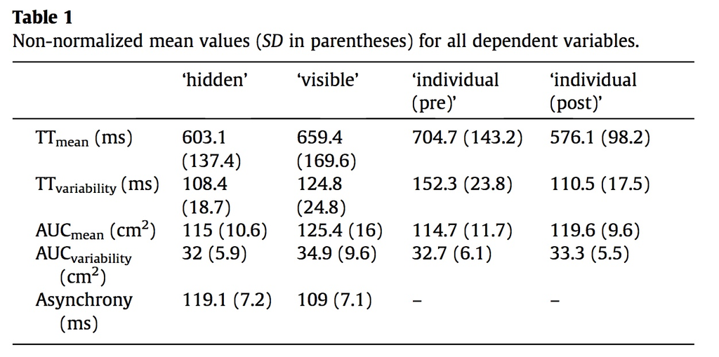

### Inferential statistics

> We compared co-actors’ normalized performance between the ‘hidden’ and ‘visible’ conditions (Fig. 2; for the non-normalized data see Table 1). In line with our hypothesis that co-actors would try to reduce the temporal variability of their actions when they could not see each other, performance was not only faster (smaller normalized TTmean), t(15) = −3.29, p < 0.01, Cohen’s d = −0.82, but also less variable (smaller normalized TTvariability), t(15) = −2.52, p < 0.05, Cohen’s d = −0.63, in the ‘hidden’ condition. In line with our hypothesis that co-actors would modulate movement parameters in a communicative manner when they could see each other, the analysis of normalized AUCmean showed a larger area under the curve in the ‘visible’ condition, t(15) = −3.82, p < 0.01, Cohen’s d = −0.96. The difference in variability of curvature (normalized AUCvariability), t(15) = −1.4, p > 0.1, Cohen’s d = −0.35, was not significant.

```r
# Note: authors only report p < X, or p > X, so cannot compare actual p-values, just intervals
reported_inferentials <- list(
  TT_mean = list(df = 15, t = -3.29, p = 0.01),
  TT_variability = list(df = 15, t = -2.52, p = 0.05),
  AUC_mean =  list(df = 15, t = -3.82, p = 0.01),
  AUC_variability = list(df = 15, t = -1.4, p = 0.1)
)

t_TT_mean <- with(df.pair.condition.summary %>% filter(key == "TT_mean"),
     t.test(Hidden_normalized, Visible_normalized, paired = T))

t_TT_variability <- with(df.pair.condition.summary %>% filter(key == "TT_variability"),
     t.test(Hidden_normalized, Visible_normalized, paired = T))

t_AUC_mean <- with(df.pair.condition.summary %>% filter(key == "AUC_mean"),
     t.test(Hidden_normalized, Visible_normalized, paired = T))

t_AUC_variability <- with(df.pair.condition.summary %>% filter(key == "AUC_variability"),
     t.test(Hidden_normalized, Visible_normalized, paired = T))

## TT mean
# DF
compareValues(reported_inferentials$TT_mean$df,
              t_TT_mean$parameter)
```

```
## [1] "MATCH. The reported value (15) and the obtained value (15) differed by 0%"
```

```r
# T Stat
compareValues(reported_inferentials$TT_mean$t,
              t_TT_mean$statistic)
```

```
## [1] "MINOR NUMERICAL ERROR. The reported value (-3.29) and the obtained value (-3.32357004055576) differed by 1.02%"
```

```r
# P value

print(paste("reported P-value < ", reported_inferentials$TT_mean$p,
      " ... obtained P-value = ", t_TT_mean$p.value, sep = ""))
```

```
## [1] "reported P-value < 0.01 ... obtained P-value = 0.00462963979500743"
```

```r
print("MATCH")
```

```
## [1] "MATCH"
```

```r
## TT variability
# DF
compareValues(reported_inferentials$TT_variability$df,
              t_TT_variability$parameter)
```

```
## [1] "MATCH. The reported value (15) and the obtained value (15) differed by 0%"
```

```r
# T Stat
compareValues(reported_inferentials$TT_variability$t,
              t_TT_variability$statistic)
```

```
## [1] "MINOR NUMERICAL ERROR. The reported value (-2.52) and the obtained value (-2.46000287420574) differed by 2.38%"
```

```r
# P value

print(paste("reported P-value < ", reported_inferentials$TT_variability$p,
      " ... obtained P-value = ", t_TT_variability$p.value, sep = ""))
```

```
## [1] "reported P-value < 0.05 ... obtained P-value = 0.0265149371276475"
```

```r
print("MATCH")
```

```
## [1] "MATCH"
```

```r
## AUC mean
# DF
compareValues(reported_inferentials$AUC_mean$df,
              t_AUC_mean$parameter)
```

```
## [1] "MATCH. The reported value (15) and the obtained value (15) differed by 0%"
```

```r
# T Stat
compareValues(reported_inferentials$AUC_mean$t,
              t_AUC_mean$statistic)
```

```
## [1] "MINOR NUMERICAL ERROR. The reported value (-3.82) and the obtained value (-3.74695260848444) differed by 1.91%"
```

```r
# P value

print(paste("reported P-value < ", reported_inferentials$AUC_mean$p,
      " ... obtained P-value = ", t_AUC_mean$p.value, sep = ""))
```

```
## [1] "reported P-value < 0.01 ... obtained P-value = 0.00194303229481894"
```

```r
print("MATCH")
```

```
## [1] "MATCH"
```

```r
## AUC variability
# DF
compareValues(reported_inferentials$AUC_variability$df,
              t_AUC_variability$parameter)
```

```
## [1] "MATCH. The reported value (15) and the obtained value (15) differed by 0%"
```

```r
# T Stat
compareValues(reported_inferentials$AUC_variability$t,
              t_AUC_variability$statistic)
```

```
## [1] "MAJOR NUMERICAL ERROR. The reported value (-1.4) and the obtained value (-2.36170156108394) differed by 68.69%"
```

```r
# P value

print(paste("reported P-value > ", reported_inferentials$AUC_variability$p,
      " ... obtained P-value = ", t_AUC_variability$p.value, sep = ""))
```

```
## [1] "reported P-value > 0.1 ... obtained P-value = 0.0321382501140984"
```

```r
print("DECISION ERROR")
```

```
## [1] "DECISION ERROR"
```

## Step 5: Conclusion

```r
codReport(Report_Type = 'pilot',
          Article_ID = 'rggwx',
          Insufficient_Information_Errors = 0,
          Decision_Errors = 1,
          Major_Numerical_Errors = 2,
          Minor_Numerical_Errors = 6)
```

| Insufficient_Information_Errors | Decision_Errors | Major_Numerical_Errors | Minor_Numerical_Errors | Final_Outcome |
| --- | --- | --- | --- | --- |
| 0 | 1 | 2 | 6 | Failure |

[output not shown]

[output cut: 68 more lines]

[output not shown]